[figure not shown]

# Python Data Visualization Exercises

*Author: Ben Shaver(DC), h/t Matt Brems (DC)*

Below are three types of data visualization exercises that can be included at the end of every lab. I've given a few examples of each.

```python
import pandas as pd
import matplotlib.pyplot as plt
import seaborn as sns
%matplotlib inline
```

### 1. What is this viz telling you?

What works? What doesn't? How does it differ from 'default settings'?

- Take a look at [this visualization](https://informationisbeautiful.net/visualizations/star-wars-last-jedi-one-of-the-biggest-rotten-tomatoes-audience-vs-critics-score-splits-ever/)

What type of graph is it? What is it telling you? How many dimensions does it have, and what are the variables? Work works with this visualization and what doesn't?

- All the visualization in [this article](https://fivethirtyeight.com/features/lionel-messi-is-impossible/) have something in common.

All of the graphs share a common design decision. What is it? How does it help make the point of the article?

- Compare the two histograms below. Which contains more information? Which is more informative? Using the code provided, create a third histogram that improves on the first two. (This uses data from the MovieLens 100k movie rating dataset, used in the DSI-DC Pandas I lecture. The goal is to get students thinking about binning choices.)

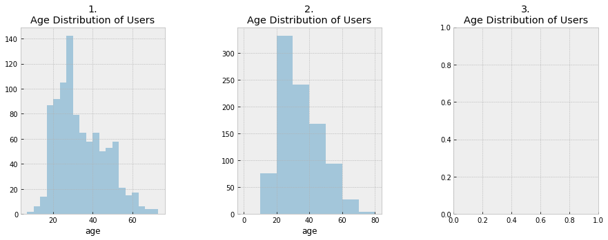

```python
users = pd.read_table('https://raw.githubusercontent.com/josephofiowa/DAT8/master/data/u.user', sep='|')

with plt.style.context(('bmh')):
    fig = plt.figure(figsize=(15,5))
    plt.subplot(1,3,1)
    sns.distplot(users['age'], kde=False, bins=20)
    plt.title('1.\nAge Distribution of Users')
    plt.subplot(1,3,2)
    sns.distplot(users['age'], kde=False, bins=[0,10,20,30,40,50,60,70,80])
    plt.title('2.\nAge Distribution of Users')
    plt.subplot(1,3,3)
    # Your code goes here:
#     sns.distplot(users['age'])
    plt.title('3.\nAge Distribution of Users')
    fig.subplots_adjust(wspace=.5)
```

- Compare the two visualizations below. How could each be improved? In general, which would you prefer? In the space provided, create a third visualization which is an improvement on both.

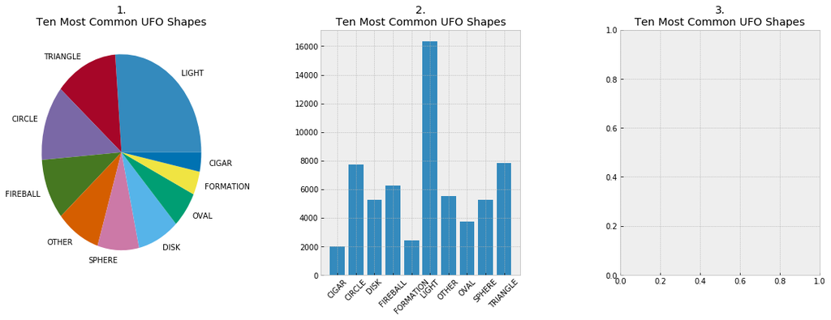

```python
ufo = pd.read_csv('https://raw.githubusercontent.com/justmarkham/DAT8/master/data/ufo.csv')

shapes = ufo['Shape Reported'].value_counts()[:10]

with plt.style.context(('bmh')):
    fig = plt.figure(figsize=(19,6))
    plt.subplot(1,3,1)
    plt.pie(shapes, labels=shapes.index)
    plt.title('1.\nTen Most Common UFO Shapes')
    plt.subplot(1,3,2)
    plt.bar(x = shapes.index, height=shapes, )
    plt.xticks(rotation =45)
    plt.title('2.\nTen Most Common UFO Shapes')
    plt.subplot(1,3,3)
    # Your code here:

    plt.title('3.\nTen Most Common UFO Shapes')
    fig.subplots_adjust(wspace=.5)
```

### 2. Recreate this viz:

(Using data from the relevant lab, or from the current project)

- (Box plot with jitter) - Run the cell below. How many plots are created? Comment every line of code, explaining what each parameter is doing. Then, create a similar graphic using data from project 1 (SAT/ACT scores) or from the current lab.

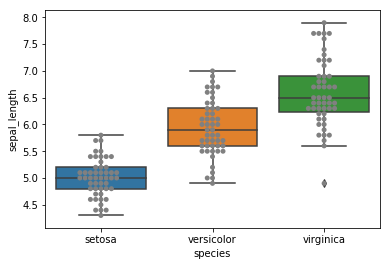

```python
# From the Python graph gallery:

df = sns.load_dataset('iris')
_ = sns.boxplot(x='species', y='sepal_length', data=df)
_ = sns.swarmplot(x='species', y='sepal_length', data=df, color="grey")
```

- Run the cell below. Which plotting libraries are used? Comment on every line.
- Creating quick and dirty plots like these can be powerful EDA. Using data from this lab, use the Pandas `.plot` method to visualize a single variable. Then, use the same method to visualize the results of a Pandas `.groupby` operation.

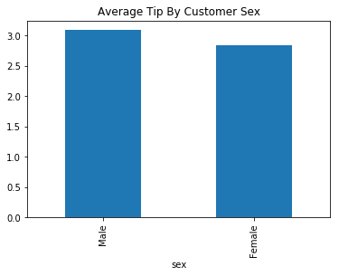

```python
df = sns.load_dataset('tips')
_ = df.groupby('sex')['tip'].mean().plot(kind='bar')
_ = plt.title('Average Tip By Customer Sex')
```

### 3. Create any viz that communicates the point.

What is the point of this viz, in one sentence?

- This is a pretty generic question, which could be adapted for the end of any lab. Here are a couple of leading questions that could be used:
  - Create one visualization that communicates your results. Include a descriptive title, and assume that this visualization is all you will be showing stakeholders.
  - Create two visualizations of different types using base Matplotlib and/or Seaborn settings. Which is better, and why? (E.g. compare a pie chart and a bar chart)
  - Visualize the distribution of some variable from this lab. Discuss your choice of graph and any changes you made to default settings. Summarize the shape of the distribution in one sentence. (E.g box plot vs histogram, number of bins)
  - You are interviewing with a non-technical HR professional. You've just explained your capstone project. Create one or two visualizations that represent the performance of your model. (E.g. true-vs-predicted values, false-positive-rate plotted against threshold values, even a confusion matrix would suffice. An ROC curve would be inappropriate here.)